# Assignment 2

## Task 1

### Step 1

Assuming that the water samples are totaly independent and have equal probability of containing Giardia Cysts then the conditional distribution of X is Binomial(116, $\theta$)

### Step 2

We want to find parameters $α$ and $β$ of a Beta distribution that for parameter $\theta$ will result in a mean of $0.2$ and a standard deviation of $0.16$.

We know that the mean of a Beta distribution is $α / (α + β)$ and the variance is $αβ / ((α + β)^2 (α + β + 1))$. Therefore we can solve for $α$ and $β$:

$0.2 = α / (α + β)$

$0.16^2 = αβ / ((α + β)^2 (α + β + 1))$

By rearranging and simplifying some parts we get:

$β = 0.8α / 0.2 = 4α$

And the result is:

$α = 21/20 ≈ 1$, $β = 4.2 ≈ 4$

Therefore prior distribution for $\theta$ is $Beta(1, 4)$

### Step 3

We update our parameters $α' = α + X = 1 + 17 = 18$ and $β' = β + n - X = 4 + 116 - 17 = 103$.

The posterior distribution of $\theta$ is:

$\theta | X = 17 ∼ Beta(18, 103)$

The posterior mean and standard deviation are:

$E(\theta | X = 17) = α' / (α' + β') ≈ 0.149$

$sd(\theta | X = 17) = sqrt(α'β' / ((α' + β')^2 (α' + β' + 1))) ≈ 0.032$

### Step 4

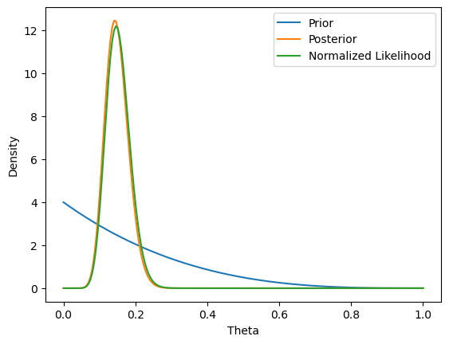

```python
import numpy as np
import matplotlib.pyplot as plt
from scipy.stats import beta, binom

# Define parameters
n = 116
x = 17
a = 1
b = 4
a_post = a + x
b_post = b + n - x
theta = np.linspace(0, 1, 200)

# Calculate distributions
prior = beta.pdf(theta, a, b)
posterior = beta.pdf(theta, a_post, b_post)
likelihood = binom.pmf(x, n, theta)
likelihood_norm = likelihood / (theta[1] - theta[0]) / likelihood.sum()

# Plot distributions
plt.plot(theta, prior, label='Prior')
plt.plot(theta, posterior, label='Posterior')
plt.plot(theta, likelihood_norm, label='Normalized Likelihood')
plt.legend()
plt.xlabel('Theta')
plt.ylabel('Density')
plt.show()
```

### Step 5

We want to find $P(\theta < 0.1 | X = 17)$. Using the Beta distribution CDF, we get:

$P(\theta < 0.1 | X = 17) = BetaCDF(0.1, 18, 103) ≈ 0.053$

So the posterior probability that $\theta$ is less than $0.1$ is quite low.

### Step 6

We want to find a central $95%$ posterior credible interval for $\theta$. Using the Beta distribution quantiles from Wolfram, we get:

$P(0.025 < \theta < 0.975 | X = 17):$

$Quantile(Beta(18, 103), 0.025) ≈ 0.091$

$Quantile(Beta(18, 103), 0.975) ≈ 0.217$

So a $95%$ credible interval for $\theta$ is $[0.091, 0.217]$.

## Task 2

### Reading the dataset & selecting top-30 cities by population

```python
import pandas as pd


df = pd.read_csv('city.csv', encoding = 'utf8')

df = df[["city", "geo_lat", "geo_lon", "population"]]

df["population"] = df["population"].apply(pd.to_numeric)

df = df.sort_values(by='population', ascending=False)[:30]

df.index = pd.RangeIndex(len(df.index))

# These are both regions and cities, so we have so amend our stuff a bit
df.loc[0, 'city'] = 'Москва'
df.loc[1, 'city'] = 'Санкт Петербург'
# rename columns
df["City"] = df["city"]
df["Lattitude"] = df["geo_lat"]
df["Longitude"] = df["geo_lon"]
df["Population"] = df["population"]
df = df.drop(["city", "geo_lat", "geo_lon", "population"], axis=1)
df.head(30)
```

|  | City | Lattitude | Longitude | Population |
| --- | --- | --- | --- | --- |
| 0 | Москва | 55.754047 | 37.620405 | 11514330 |
| 1 | Санкт Петербург | 59.939131 | 30.315900 | 4848742 |
| 2 | Новосибирск | 55.028191 | 82.921149 | 1498921 |
| 3 | Екатеринбург | 56.838522 | 60.605491 | 1377738 |
| 4 | Нижний Новгород | 56.324063 | 44.005391 | 1250615 |
| 5 | Казань | 55.794358 | 49.111497 | 1216965 |
| 6 | Самара | 53.195031 | 50.106952 | 1164900 |
| 7 | Омск | 54.984857 | 73.367452 | 1154000 |
| 8 | Челябинск | 55.160262 | 61.400808 | 1130273 |
| 9 | Ростов-на-Дону | 47.222457 | 39.718803 | 1091544 |
| 10 | Уфа | 54.734944 | 55.957847 | 1062300 |
| 11 | Волгоград | 48.707004 | 44.517034 | 1021244 |
| 12 | Пермь | 58.010258 | 56.234203 | 1000679 |
| 13 | Красноярск | 56.009388 | 92.852481 | 973826 |
| 14 | Воронеж | 51.659333 | 39.196923 | 889680 |
| 15 | Саратов | 51.533557 | 46.034257 | 836900 |
| 16 | Краснодар | 45.040160 | 38.975965 | 744933 |
| 17 | Тольятти | 53.520535 | 49.389403 | 719484 |
| 18 | Барнаул | 53.347997 | 83.779806 | 635585 |
| 19 | Ижевск | 56.852738 | 53.211490 | 628117 |
| 20 | Ульяновск | 54.307941 | 48.374849 | 613793 |
| 21 | Владивосток | 43.116490 | 131.882394 | 592069 |
| 22 | Ярославль | 57.621548 | 39.897741 | 591486 |
| 23 | Иркутск | 52.286404 | 104.280747 | 587225 |
| 24 | Тюмень | 57.152974 | 65.534410 | 581758 |
| 25 | Махачкала | 42.984916 | 47.504718 | 577990 |
| 26 | Хабаровск | 48.464726 | 135.059894 | 577668 |
| 27 | Оренбург | 51.787509 | 55.101883 | 570329 |
| 28 | Новокузнецк | 53.794315 | 87.214275 | 547885 |
| 29 | Кемерово | 55.391065 | 86.046778 | 532884 |

```python
import json

with open('russia.json') as f:
    rdata = json.load(f)
# we do not need data with negative longitude
rdata = rdata[0]['geojson']['coordinates'][4:]
```

### Plotting helpers

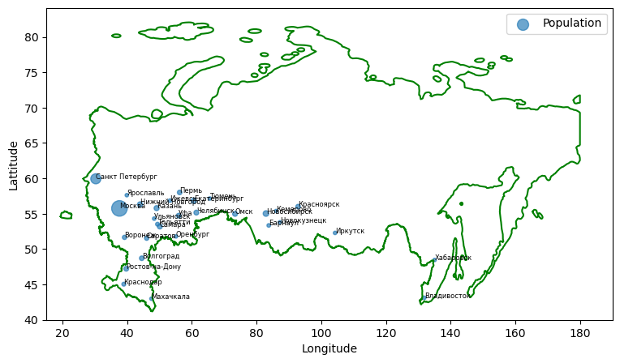

```python
# commit a bunch of crimes by having an old map, lol
def plot_russia(ax, rdata):
    for p in rdata:
        pc = np.array(p)[0]
        ax.plot(pc[:, 0], pc[:, 1], color='green')
    ax.set_xlim(15, 190)
    ax.set_ylim(40, None)

def plot_cities(ax, cit):
    cit.plot.scatter(ax=ax, x='Longitude', y='Lattitude', s=cit['Population']/60000, label='Population', alpha=0.65,)
    for pos, name in enumerate(cit['City']):
        ax.annotate(name, (cit['Longitude'].iloc[pos], cit['Lattitude'].iloc[pos]), size=6)
    ax.legend()

def plot_path(ax, coords, path):
    path_coord = coords[np.concatenate([path, [path[0]]])]
    return ax.plot(path_coord[:, 1], path_coord[:, 0], color="blue", linewidth=1.5, alpha=1)

def plot_convergence(ax, temps, distances, ann_rate):
    t = np.arange(len(distances))

    ax.set_xlabel('Number of Iterations')
    ax.set_ylabel('distance', color="blue")
    ax.plot(t, distances, color="blue", alpha=0.9)
    ax.tick_params(axis='y', labelcolor="blue")

    ax_temp = ax.twinx()
    ax_temp.set_ylabel('Temperature', color="red")
    ax_temp.plot(t, temps, color="red", alpha=0.6)
    ax_temp.tick_params(axis="y", labelcolor="red")
    ax_temp.set_title(f'Convergence of SImulated Annealing with rate = {ann_rate}')



fig, ax = plt.subplots(figsize=(9,5))
plot_russia(ax, rdata)
plot_cities(ax, df)
```

### Animation Helper

```python
%matplotlib inline
from matplotlib.animation import FuncAnimation
class TravelingSalesmanRussianCitiesAnimation():
    """ Animation of SA for the Traveling Salesman problem. """
    def __init__(self, ax, travpaths, pathdists, temperatures, ann_rate, cities=df, russia=rdata):
        self.travpaths = travpaths
        self.pathdists = pathdists
        self.temperatures = temperatures
        self.ann_rate = ann_rate
        self.cities = cities
        self.coordinates = self.cities[['Lattitude', 'Longitude']].values

        self.ax = ax

        plot_russia(ax, russia)
        plot_cities(self.ax, self.cities)

        self.pathplot = plot_path(self.ax, self.coordinates, self.travpaths[0])
        self.set_title(self.temperatures[0], self.pathdists[0])

    def init(self):
        self.ax.lines[-1].remove()
        self.pathplot = plot_path(self.ax, self.coordinates, self.travpaths[0])
        self.set_title(self.temperatures[0], self.pathdists[0])
        return self.pathplot,

    def set_title(self, T, d):
        self.ax.set_title(f'Annealing rate = {self.ann_rate}, T = {T:.3f}, Optimal Distance = {d:.2f}km')

    def __call__(self, i):
        if i == 0:
            return self.init()

        if i < len(self.travpaths):
            if not np.array_equal(self.travpaths[i], self.travpaths[i-1]):
                # updating path only if it differs from the previously plotted
                self.ax.lines[-1].remove()
                self.pathplot = plot_path(self.ax, self.coordinates, self.travpaths[i])
            if self.temperatures[i] != self.temperatures[i-1] or self.pathdists[i] != self.pathdists[i-1]:
                # updating title only if it differs from the previous title
                self.set_title(self.temperatures[i], self.pathdists[i])
        return self.pathplot,
```

### Distance computing helpers

```python
def swap_cities(travpath, a, b):
    travpath[a], travpath[b] = travpath[b], travpath[a]

def distance(travpath, distances):
    res = distances[travpath[-1]][travpath[0]]
    for i in range(len(travpath) - 1):
        res += distances[travpath[i]][travpath[i+1]]
    return res

def swap_distance_difference(travpath, distances, a, b):
    pd = distance(travpath, distances)
    swap_cities(travpath, a, b)
    pd1 = distance(travpath, distances)
    swap_cities(travpath, a, b)
    return pd1-pd

#Compute proper geodistance for cities pairwise
from geopy.distance import great_circle

coords = df[["Lattitude", "Longitude"]].values
distances = np.array([[great_circle(a, b).km for a in coords] for b in coords])
```

### Simulated Annealing helper

```python
import warnings
warnings.filterwarnings("ignore")
from tqdm.notebook import tqdm

def p(E_x, T=1.0):
    return np.exp(-E_x / T)

def generate_pair_of_different_numbers(mi, ma):
    a = b = 0
    i = 0
    while a == b:
        i+=1
        if i > 1000000:
            # there must be no options
            raise Exception(f"Cannot generate two non equal numbers from {mi} to {ma}")
        a, b = sorted(np.random.randint(low=mi, high=ma, size=2))
    return a, b

def generate_list_of_temps(T_0, T_cool, ann_rate, cooling_it):
    T = T_0
    list_temps = [T_0]
    time = 0
    while T > T_cool:
        time += 1
        if time % cooling_it == 0:
            T *= ann_rate
            list_temps.append(T)
    return list_temps


def simulate_annealing(initial_path, T_0, T_cool, ann_rate, cooling_it=4):
    currpath = initial_path
    currdist = distance(currpath, distances)
    paths, histdistances = [currpath.copy()], [currdist]

    temps = generate_list_of_temps(T_0, T_cool, ann_rate, cooling_it)
    for T in tqdm(temps):


        # try generating a pair nicely
        a, b = generate_pair_of_different_numbers(0, 30)
        newdist = currdist + swap_distance_difference(currpath, distances, a, b)
        alpha = p(newdist, T) / p(currdist, T)

        # now try generating a pair horribly
        if np.isnan(alpha):
            nonan_exchanges = []
            for i in range(distances.shape[0]):
                for j in range(i+1, distances.shape[0]):
                    newdist = currdist + swap_distance_difference(currpath, distances, i, j)
                    alpha = p(newdist, T) / p(currdist, T)
                    if not np.isnan(alpha):
                        nonan_exchanges.append((i, j))

            if not nonan_exchanges:
                # truncate temps and finish early
                temps = temps[:len(histdistances)]
                break

            a, b = nonan_exchanges[np.random.randint(low=0, high=len(nonan_exchanges))]
            newdist = currdist + swap_distance_difference(currpath, distances, a, b)
            alpha = p(newdist, T) / p(currdist, T)

        if np.random.uniform(0, 1) <= alpha:
            # accept this new path
            currdist = newdist
            swap_cities(currpath, a, b)
        # store data for plotting later
        paths.append(currpath.copy())
        histdistances.append(currdist)

    return np.array(paths), np.array(histdistances), np.array(temps)
```

### Experiments

```python
def get_starting_path():
    np.random.seed(42)
    path = np.arange(30)
    np.random.shuffle(path)
    return path
```

### Fast Cooling (0.9)

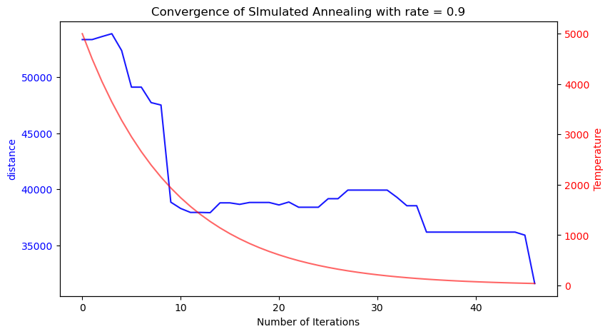

[video not shown]

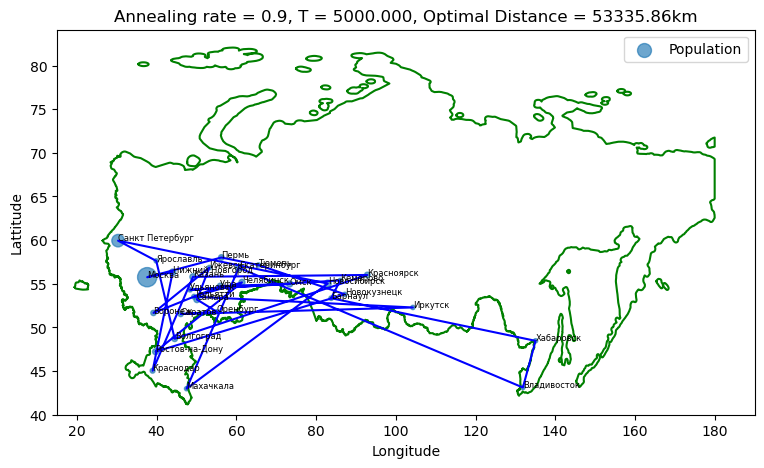

```python
starting_path = get_starting_path()

ann_rate = 0.9
paths, histdistances, temps = simulate_annealing(starting_path, T_0=5000, T_cool=1, ann_rate=ann_rate)

fig, ax = plt.subplots(figsize=(9,5))
plot_convergence(ax, temps, histdistances, ann_rate=ann_rate)
plt.show()

fig, ax = plt.subplots(figsize=(9,5))

TSRCA = TravelingSalesmanRussianCitiesAnimation(ax, paths, histdistances, temps, ann_rate)
anim = FuncAnimation(fig, TSRCA, init_func=TSRCA.init,
                     frames=len(histdistances), repeat=False,
                     save_count=1, interval=1, blit=False)

# I use HTML because matplotlin animations are full of bugs
# Sometimes they make all of the plots permanently disappear
# Sometimes they randomly break themselves
# God, why do we do this
# Please do not ask why there is a random plot after the animation
# I have no clue

from matplotlib.animation import FFMpegWriter
writer = FFMpegWriter(fps=5, bitrate=None)
anim.save("results/" + 'cool_fast.mp4', writer=writer)

from IPython.display import HTML
HTML(anim.to_html5_video())
```

### Average Cooling (0.95)

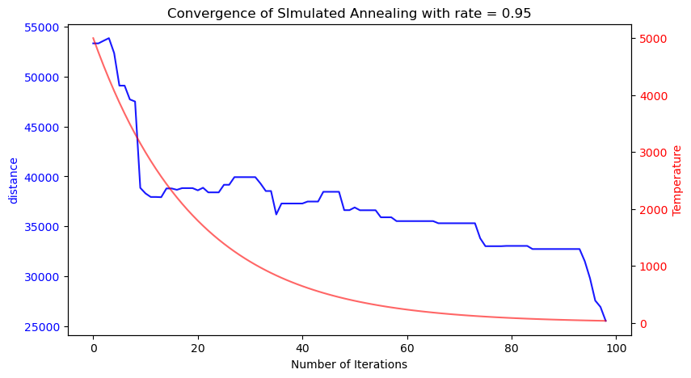

[video not shown]

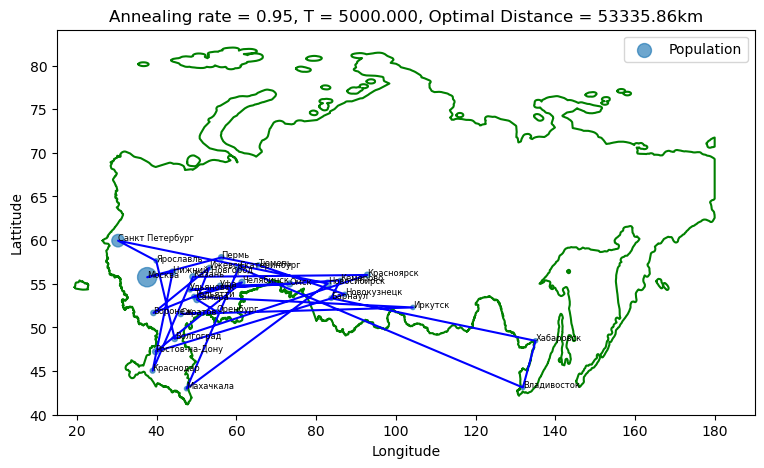

```python
starting_path = get_starting_path()

ann_rate = 0.95
paths, histdistances, temps = simulate_annealing(starting_path, T_0=5000, T_cool=1, ann_rate=ann_rate)

fig, ax = plt.subplots(figsize=(9,5))
plot_convergence(ax, temps, histdistances, ann_rate=ann_rate)
plt.show()

fig, ax = plt.subplots(figsize=(9,5))

TSRCA = TravelingSalesmanRussianCitiesAnimation(ax, paths, histdistances, temps, ann_rate)
anim = FuncAnimation(fig, TSRCA, init_func=TSRCA.init,
                     frames=len(histdistances), repeat=False,
                     save_count=1, interval=1, blit=False)

from matplotlib.animation import FFMpegWriter
writer = FFMpegWriter(fps=5, bitrate=None)
anim.save("results/" + 'cool_average.mp4', writer=writer)

from IPython.display import HTML
HTML(anim.to_html5_video())
```

### Sluggish cooling (0.99)

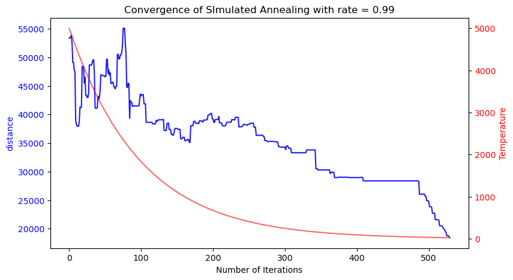

[video not shown]

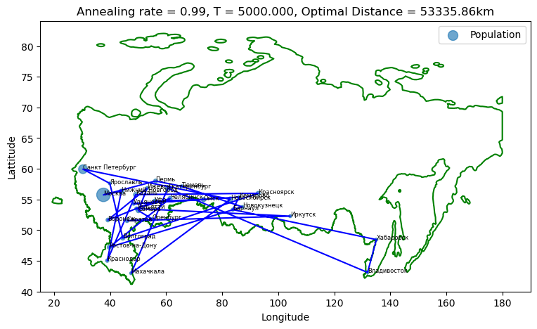

```python
starting_path = get_starting_path()

ann_rate = 0.99
paths, histdistances, temps = simulate_annealing(starting_path, T_0=5000, T_cool=1, ann_rate=ann_rate)

fig, ax = plt.subplots(figsize=(9,5))
plot_convergence(ax, temps, histdistances, ann_rate=ann_rate)
plt.show()

fig, ax = plt.subplots(figsize=(9,5))

TSRCA = TravelingSalesmanRussianCitiesAnimation(ax, paths, histdistances, temps, ann_rate)
anim = FuncAnimation(fig, TSRCA, init_func=TSRCA.init,
                     frames=len(histdistances), repeat=False,
                     save_count=1, interval=1, blit=False)

from matplotlib.animation import FFMpegWriter
writer = FFMpegWriter(fps=5, bitrate=None)
anim.save("results/" + 'cool_sluggish.mp4', writer=writer)

from IPython.display import HTML
HTML(anim.to_html5_video())
```

### Compare convergence speed

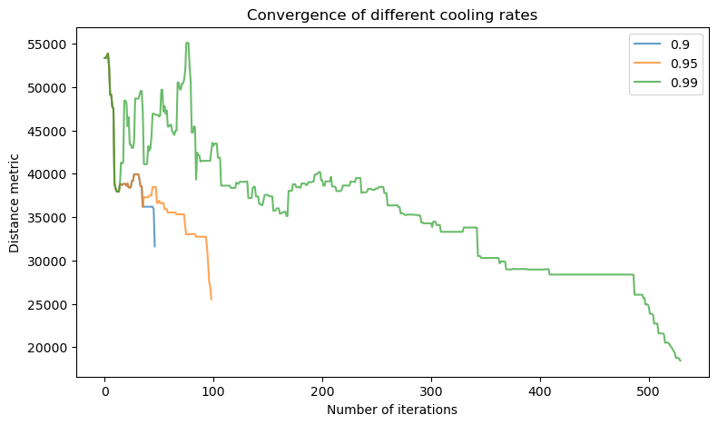

```python
starting_path = get_starting_path()
paths1, histdistances1, temps1 = simulate_annealing(starting_path, T_0=5000, T_cool=1, ann_rate=0.9)
starting_path = get_starting_path()
paths2, histdistances2, temps2 = simulate_annealing(starting_path, T_0=5000, T_cool=1, ann_rate=0.95)
starting_path = get_starting_path()
paths3, histdistances3, temps3 = simulate_annealing(starting_path, T_0=5000, T_cool=1, ann_rate=0.99)



fig, ax = plt.subplots(figsize=(9,5))

ax.set_title(f'Convergence of different cooling rates')
ax.set_xlabel('Number of iterations')
ax.set_ylabel('Distance metric')

ax.plot(np.arange(len(histdistances1)),  histdistances1,  label=0.9,   alpha=0.7)
ax.plot(np.arange(len(histdistances2)),  histdistances2,  label=0.95,  alpha=0.7)
ax.plot(np.arange(len(histdistances3)),  histdistances3,  label=0.99,  alpha=0.7)

ax.legend()
plt.show()
```

### My comments on the results

Simulated annealing is pretty cool (pun intended) and it indeed does to some extent "solve" the TSP. However there is no guarantee that we will converge to the best solution and not to a random locl minimum.

Different cooling rates obviously work differently. Since cooling rate practically controls the tradeoff between exploration and exploitation.

Faster cooling allows us to get less iterations and therefore make things faster. However this does come with a hefty tradeoff in performance.

Slower cooling rate is much better at exploring and does find greener pastures, however it does take a while to do so.

The most surprising thing to me is that when temperature starts to get low all of the cooling rates very quickly decrease distance by exploitation. I would expect this decrease not to be this quick and this big.